# Table of Contents

```python
import pandas as pd
import numpy as np
import seaborn as sns
from matplotlib import pyplot as plt
from sklearn.metrics import mean_absolute_error
from sklearn.dummy import DummyClassifier
from sklearn.ensemble import RandomForestRegressor
from sklearn.linear_model import LinearRegression
from sklearn.model_selection import cross_val_score
import warnings
warnings.filterwarnings('ignore')
```

```python
from sklearn.metrics import make_scorer
from sklearn.model_selection import cross_val_score
from sklearn.model_selection import RandomizedSearchCV
from catboost import CatBoostRegressor
```

```python
pd.options.display.max_columns = None
pd.options.display.max_rows = None
```

# Восстановление золота из руды

## Описание проекта

**Заказчик** - компания «Цифры», разрабатывающая решения для эффективной работы промышленных предприятий.

Необходимо разработать прототип модели машинного обучения, которая будет помогать оптимизировать производство, чтобы не запускать предприятие с убыточными характеристиками. Модель должна предсказать коэффициент восстановления золота из золотосодержащей руды.

**Исходные данные** - данные с параметрами добычи и очистки.

Данные индексируются датой и временем получения информации (признак date). Соседние по времени параметры часто похожи. Некоторые параметры недоступны, потому что замеряются и/или рассчитываются значительно позже. Из-за этого в тестовой выборке отсутствуют некоторые признаки, которые могут быть в обучающей.

**Наименование признаков**

Наименование признаков имеет следующую форму:

[этап].[тип_параметра].[название_параметра]

Возможные значения для блока [этап]:

- rougher — флотация
- primary_cleaner — первичная очистка
- secondary_cleaner — вторичная очистка
- final — финальные характеристики

Возможные значения для блока [тип_параметра]:

- input — параметры сырья
- output — параметры продукта
- state — параметры, характеризующие текущее состояние этапа
- calculation — расчётные характеристики

## Описание и предобработка данных

### Загрузка и описание данных

Начнем с загрузки исходных данных и проведения первичного анализа.

```python
try:
    data_full = pd.read_csv('gold_recovery_full_new.csv')
    data_train = pd.read_csv('gold_recovery_train_new.csv')
    data_test = pd.read_csv('gold_recovery_test_new.csv')
except:
    data_full = pd.read_csv('/datasets/gold_recovery_full_new.csv')
    data_train = pd.read_csv('/datasets/gold_recovery_train_new.csv')
    data_test = pd.read_csv('/datasets/gold_recovery_test_new.csv')
```

```python
for data in [data_full, data_train, data_test]:
    display(data.info())
    display(data.head(5))
    print()
```

```
<class 'pandas.core.frame.DataFrame'>
RangeIndex: 19439 entries, 0 to 19438
Data columns (total 87 columns):
 #   Column                                              Non-Null Count  Dtype
---  ------                                              --------------  -----
 0   date                                                19439 non-null  object
 1   final.output.concentrate_ag                         19438 non-null  float64
 2   final.output.concentrate_pb                         19438 non-null  float64
 3   final.output.concentrate_sol                        19228 non-null  float64
 4   final.output.concentrate_au                         19439 non-null  float64
 5   final.output.recovery                               19439 non-null  float64
 6   final.output.tail_ag                                19438 non-null  float64
 7   final.output.tail_pb                                19338 non-null  float64
 8   final.output.tail_sol                               19433 non-null  float64
 9   final.output.tail_au                                19439 non-null  float64
```

[output cut: 79 more lines]

```
None
```

|  | date | final.output.concentrate_ag | final.output.concentrate_pb | final.output.concentrate_sol | final.output.concentrate_au | final.output.recovery | final.output.tail_ag | final.output.tail_pb | final.output.tail_sol | final.output.tail_au | primary_cleaner.input.sulfate | primary_cleaner.input.depressant | primary_cleaner.input.feed_size | primary_cleaner.input.xanthate | primary_cleaner.output.concentrate_ag | primary_cleaner.output.concentrate_pb | primary_cleaner.output.concentrate_sol | primary_cleaner.output.concentrate_au | primary_cleaner.output.tail_ag | primary_cleaner.output.tail_pb | primary_cleaner.output.tail_sol | primary_cleaner.output.tail_au | primary_cleaner.state.floatbank8_a_air | primary_cleaner.state.floatbank8_a_level | primary_cleaner.state.floatbank8_b_air | primary_cleaner.state.floatbank8_b_level | primary_cleaner.state.floatbank8_c_air | primary_cleaner.state.floatbank8_c_level | primary_cleaner.state.floatbank8_d_air | … |
| --- | --- | --- | --- | --- | --- | --- | --- | --- | --- | --- | --- | --- | --- | --- | --- | --- | --- | --- | --- | --- | --- | --- | --- | --- | --- | --- | --- | --- | --- | --- |
| 0 | 2016-01-15 00:00:00 | 6.055403 | 9.889648 | 5.507324 | 42.192020 | 70.541216 | 10.411962 | 0.895447 | 16.904297 | 2.143149 | 127.092003 | 10.128295 | 7.25 | 0.988759 | 8.547551 | 10.389648 | 19.529297 | 34.174427 | 14.936526 | 2.534912 | 7.476074 | 2.106679 | 1549.775757 | -498.912140 | 1551.434204 | -516.403442 | 1549.873901 | -498.666595 | 1554.367432 | … |
| 1 | 2016-01-15 01:00:00 | 6.029369 | 9.968944 | 5.257781 | 42.701629 | 69.266198 | 10.462676 | 0.927452 | 16.634514 | 2.224930 | 125.629232 | 10.296251 | 7.25 | 1.002663 | 8.558743 | 10.497069 | 19.369147 | 34.118526 | 16.250511 | 3.049646 | 6.733907 | 2.353017 | 1576.166671 | -500.904965 | 1575.950626 | -499.865889 | 1575.994189 | -499.315107 | 1574.479259 | … |
| 2 | 2016-01-15 02:00:00 | 6.055926 | 10.213995 | 5.383759 | 42.657501 | 68.116445 | 10.507046 | 0.953716 | 16.208849 | 2.257889 | 123.819808 | 11.316280 | 7.25 | 0.991265 | 8.603505 | 10.354494 | 19.167579 | 33.969464 | 16.491823 | 3.124664 | 6.471768 | 2.416800 | 1601.556163 | -499.997791 | 1600.386685 | -500.607762 | 1602.003542 | -500.870069 | 1599.541515 | … |
| 3 | 2016-01-15 03:00:00 | 6.047977 | 9.977019 | 4.858634 | 42.689819 | 68.347543 | 10.422762 | 0.883763 | 16.532835 | 2.146849 | 122.270188 | 11.322140 | 7.25 | 0.996739 | 7.221879 | 8.496563 | 15.978538 | 28.260743 | 16.024359 | 2.960362 | 6.843791 | 2.262051 | 1599.968720 | -500.951778 | 1600.659236 | -499.677094 | 1600.304144 | -500.727997 | 1600.449520 | … |
| 4 | 2016-01-15 04:00:00 | 6.148599 | 10.142511 | 4.939416 | 42.774141 | 66.927016 | 10.360302 | 0.792826 | 16.525686 | 2.055292 | 117.988169 | 11.913613 | 7.25 | 1.009869 | 9.089428 | 9.986786 | 19.199864 | 33.044932 | 16.480185 | 3.112100 | 6.550154 | 2.277073 | 1601.339707 | -498.975456 | 1601.437854 | -500.323246 | 1599.581894 | -500.888152 | 1602.649541 | … |

```
<class 'pandas.core.frame.DataFrame'>
RangeIndex: 14149 entries, 0 to 14148
Data columns (total 87 columns):
 #   Column                                              Non-Null Count  Dtype
---  ------                                              --------------  -----
 0   date                                                14149 non-null  object
 1   final.output.concentrate_ag                         14148 non-null  float64
 2   final.output.concentrate_pb                         14148 non-null  float64
 3   final.output.concentrate_sol                        13938 non-null  float64
 4   final.output.concentrate_au                         14149 non-null  float64
 5   final.output.recovery                               14149 non-null  float64
 6   final.output.tail_ag                                14149 non-null  float64
 7   final.output.tail_pb                                14049 non-null  float64
 8   final.output.tail_sol                               14144 non-null  float64
 9   final.output.tail_au                                14149 non-null  float64
```

[output cut: 79 more lines]

```
None
```

|  | date | final.output.concentrate_ag | final.output.concentrate_pb | final.output.concentrate_sol | final.output.concentrate_au | final.output.recovery | final.output.tail_ag | final.output.tail_pb | final.output.tail_sol | final.output.tail_au | primary_cleaner.input.sulfate | primary_cleaner.input.depressant | primary_cleaner.input.feed_size | primary_cleaner.input.xanthate | primary_cleaner.output.concentrate_ag | primary_cleaner.output.concentrate_pb | primary_cleaner.output.concentrate_sol | primary_cleaner.output.concentrate_au | primary_cleaner.output.tail_ag | primary_cleaner.output.tail_pb | primary_cleaner.output.tail_sol | primary_cleaner.output.tail_au | primary_cleaner.state.floatbank8_a_air | primary_cleaner.state.floatbank8_a_level | primary_cleaner.state.floatbank8_b_air | primary_cleaner.state.floatbank8_b_level | primary_cleaner.state.floatbank8_c_air | primary_cleaner.state.floatbank8_c_level | primary_cleaner.state.floatbank8_d_air | … |
| --- | --- | --- | --- | --- | --- | --- | --- | --- | --- | --- | --- | --- | --- | --- | --- | --- | --- | --- | --- | --- | --- | --- | --- | --- | --- | --- | --- | --- | --- | --- |
| 0 | 2016-01-15 00:00:00 | 6.055403 | 9.889648 | 5.507324 | 42.192020 | 70.541216 | 10.411962 | 0.895447 | 16.904297 | 2.143149 | 127.092003 | 10.128295 | 7.25 | 0.988759 | 8.547551 | 10.389648 | 19.529297 | 34.174427 | 14.936526 | 2.534912 | 7.476074 | 2.106679 | 1549.775757 | -498.912140 | 1551.434204 | -516.403442 | 1549.873901 | -498.666595 | 1554.367432 | … |
| 1 | 2016-01-15 01:00:00 | 6.029369 | 9.968944 | 5.257781 | 42.701629 | 69.266198 | 10.462676 | 0.927452 | 16.634514 | 2.224930 | 125.629232 | 10.296251 | 7.25 | 1.002663 | 8.558743 | 10.497069 | 19.369147 | 34.118526 | 16.250511 | 3.049646 | 6.733907 | 2.353017 | 1576.166671 | -500.904965 | 1575.950626 | -499.865889 | 1575.994189 | -499.315107 | 1574.479259 | … |
| 2 | 2016-01-15 02:00:00 | 6.055926 | 10.213995 | 5.383759 | 42.657501 | 68.116445 | 10.507046 | 0.953716 | 16.208849 | 2.257889 | 123.819808 | 11.316280 | 7.25 | 0.991265 | 8.603505 | 10.354494 | 19.167579 | 33.969464 | 16.491823 | 3.124664 | 6.471768 | 2.416800 | 1601.556163 | -499.997791 | 1600.386685 | -500.607762 | 1602.003542 | -500.870069 | 1599.541515 | … |
| 3 | 2016-01-15 03:00:00 | 6.047977 | 9.977019 | 4.858634 | 42.689819 | 68.347543 | 10.422762 | 0.883763 | 16.532835 | 2.146849 | 122.270188 | 11.322140 | 7.25 | 0.996739 | 7.221879 | 8.496563 | 15.978538 | 28.260743 | 16.024359 | 2.960362 | 6.843791 | 2.262051 | 1599.968720 | -500.951778 | 1600.659236 | -499.677094 | 1600.304144 | -500.727997 | 1600.449520 | … |
| 4 | 2016-01-15 04:00:00 | 6.148599 | 10.142511 | 4.939416 | 42.774141 | 66.927016 | 10.360302 | 0.792826 | 16.525686 | 2.055292 | 117.988169 | 11.913613 | 7.25 | 1.009869 | 9.089428 | 9.986786 | 19.199864 | 33.044932 | 16.480185 | 3.112100 | 6.550154 | 2.277073 | 1601.339707 | -498.975456 | 1601.437854 | -500.323246 | 1599.581894 | -500.888152 | 1602.649541 | … |

```
<class 'pandas.core.frame.DataFrame'>
RangeIndex: 5290 entries, 0 to 5289
Data columns (total 53 columns):
 #   Column                                      Non-Null Count  Dtype
---  ------                                      --------------  -----
 0   date                                        5290 non-null   object
 1   primary_cleaner.input.sulfate               5286 non-null   float64
 2   primary_cleaner.input.depressant            5285 non-null   float64
 3   primary_cleaner.input.feed_size             5290 non-null   float64
 4   primary_cleaner.input.xanthate              5286 non-null   float64
 5   primary_cleaner.state.floatbank8_a_air      5290 non-null   float64
 6   primary_cleaner.state.floatbank8_a_level    5290 non-null   float64
 7   primary_cleaner.state.floatbank8_b_air      5290 non-null   float64
 8   primary_cleaner.state.floatbank8_b_level    5290 non-null   float64
 9   primary_cleaner.state.floatbank8_c_air      5290 non-null   float64
```

[output cut: 45 more lines]

```
None
```

|  | date | primary_cleaner.input.sulfate | primary_cleaner.input.depressant | primary_cleaner.input.feed_size | primary_cleaner.input.xanthate | primary_cleaner.state.floatbank8_a_air | primary_cleaner.state.floatbank8_a_level | primary_cleaner.state.floatbank8_b_air | primary_cleaner.state.floatbank8_b_level | primary_cleaner.state.floatbank8_c_air | primary_cleaner.state.floatbank8_c_level | primary_cleaner.state.floatbank8_d_air | primary_cleaner.state.floatbank8_d_level | rougher.input.feed_ag | rougher.input.feed_pb | rougher.input.feed_rate | rougher.input.feed_size | rougher.input.feed_sol | rougher.input.feed_au | rougher.input.floatbank10_sulfate | rougher.input.floatbank10_xanthate | rougher.input.floatbank11_sulfate | rougher.input.floatbank11_xanthate | rougher.state.floatbank10_a_air | rougher.state.floatbank10_a_level | rougher.state.floatbank10_b_air | rougher.state.floatbank10_b_level | rougher.state.floatbank10_c_air | rougher.state.floatbank10_c_level | … |
| --- | --- | --- | --- | --- | --- | --- | --- | --- | --- | --- | --- | --- | --- | --- | --- | --- | --- | --- | --- | --- | --- | --- | --- | --- | --- | --- | --- | --- | --- | --- |
| 0 | 2016-09-01 00:59:59 | 210.800909 | 14.993118 | 8.080000 | 1.005021 | 1398.981301 | -500.225577 | 1399.144926 | -499.919735 | 1400.102998 | -500.704369 | 1399.001695 | -499.485144 | 13.128569 | 5.636710 | 489.793655 | 62.710452 | 42.022440 | 12.084103 | 16.922877 | 6.153479 | 16.867518 | 6.150709 | 1001.849317 | -350.301265 | 1249.738612 | -399.107531 | 1249.750520 | -399.396730 | … |
| 1 | 2016-09-01 01:59:59 | 215.392455 | 14.987471 | 8.080000 | 0.990469 | 1398.777912 | -500.057435 | 1398.055362 | -499.778182 | 1396.151033 | -499.240168 | 1399.508091 | -500.416324 | 13.036280 | 5.526065 | 490.104534 | 61.961163 | 41.187903 | 11.918977 | 17.002532 | 5.999043 | 16.996063 | 6.002315 | 998.690785 | -350.425704 | 1248.395457 | -399.946025 | 1249.514451 | -399.630810 | … |
| 2 | 2016-09-01 02:59:59 | 215.259946 | 12.884934 | 7.786667 | 0.996043 | 1398.493666 | -500.868360 | 1398.860436 | -499.764529 | 1398.075709 | -502.151509 | 1399.497088 | -499.715479 | 13.138412 | 5.426561 | 489.617969 | 66.903807 | 42.546294 | 12.091332 | 16.992520 | 5.850632 | 16.982096 | 5.853594 | 998.516720 | -349.783538 | 1247.440748 | -400.264330 | 1248.207204 | -401.074405 | … |
| 3 | 2016-09-01 03:59:59 | 215.336236 | 12.006805 | 7.640000 | 0.863514 | 1399.618111 | -498.863574 | 1397.440120 | -499.211024 | 1400.129303 | -498.355873 | 1401.065165 | -501.038738 | 12.400507 | 5.114758 | 476.618130 | 59.865919 | 41.060195 | 12.181597 | 16.532144 | 5.801935 | 16.515277 | 5.803657 | 1000.276604 | -350.172597 | 1251.322675 | -398.655289 | 1250.493702 | -399.746728 | … |
| 4 | 2016-09-01 04:59:59 | 199.099327 | 10.682530 | 7.530000 | 0.805575 | 1401.268123 | -500.808305 | 1398.128818 | -499.504543 | 1402.172226 | -500.810606 | 1399.480508 | -499.374053 | 11.327427 | 4.767383 | 488.248117 | 63.315324 | 41.269161 | 11.290425 | 13.607257 | 5.738081 | 13.650053 | 5.739634 | 996.541302 | -350.562517 | 1304.658848 | -399.511519 | 1306.455515 | -399.050685 | … |

Изначально нам доступно три набора данных - тренировочная выборка, тестовая выборка, а также объединенный и более подробный набор исходных данных. Рассмотрим первые два более подробно - именно с этими данными нам предстоит работать в дальнейшем.

Тренировочная выборка состоит из порядка 14 тыс. наблюдений. В наборе присутствует информация о 87 характеристиках. Подавляющее большинство из них имеет тип `float`. Исключение - дата и время получения информации, которые используются в качестве уникального идентификатора наблюдений. Данная переменная имеет тип `object`. Как можно заметить, данные не полные - многие переменные имеют пропуски. Поскольку перед нами стоит задача создания модели машинного обучения, чтобы не потерять наблюдения с пропусками, нам будет необходимо в дальнейшем решить проблему пропусков. Первичный взгляд на данные не позволяет выявить наличие потенциальных аномалий, поэтому будет необходимо провести дополнительный анализ относительно данного момента.

Перейдем к тестовым данным, состоящим из 5,3 тыс. наблюдениям. В отличие от тренировочных данных, тестовые включают только 53 переменные - их тип также преимущественно `float`. Такое различие в количестве переменных объясняется следующим образом - некоторые параметры недоступны, потому что замеряются и/или рассчитываются значительно позже. Это важная деталь, которая окажет значимое влияние на этапе моделирования - мы не можем использовать все характеристике, доступные в тренировочных данных. Именно поэтому нам в дальнейшем будет необходимо провести отбор признаков. Кроме того, в тренировочных данных также присутствуют пропуски.

### Проверка данных и расчет эффективности

Теперь, после первичного анализа, перейдем к более детальной работе над данными. Заказчик отметил, что предоставленные нам исходные данные являются сырыми - их просто выгрузили из хранилища. Поэтому, прежде чем приступить к построению модели, нам необходимо проверить их на корректность.

Особое внимание стоит уделить переменной, отвечающей за эффективность обогащения после этапа флотации. Именно данная переменная является одним из таргетов нашего проекта. Проверим, что она была рассчитана правильно, после чего сравним с исходным значением признака.

**Расчёт эффективности**

Для удобства опишем, как происходит расчет коэффициента эффективности обогащения.

Эффективность обогащения рассчитывается по формуле

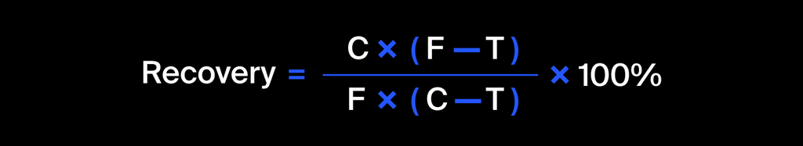

где:

- C — доля золота в концентрате после флотации/очистки;
- F — доля золота в сырье/концентрате до флотации/очистки;
- T — доля золота в отвальных хвостах после флотации/очистки.

```python
C_roughe = data_train['rougher.output.concentrate_au']
F_roughe = data_train['rougher.input.feed_au']
T_roughe = data_train['rougher.output.tail_au']
```

```python
data_train['rougher.output.recovery_new'] = (C_roughe*(F_roughe-T_roughe))/(F_roughe*(C_roughe-T_roughe))*100
print('Средняя абсолютная ошибка между исходным и расчитанным коэффициентом эффективности обогощения:',
      mean_absolute_error(data_train['rougher.output.recovery_new'], data_train['rougher.output.recovery']))
```

```
Средняя абсолютная ошибка между исходным и расчитанным коэффициентом эффективности обогощения: 9.73512347450521e-15
```

Как можно заметить, рассчитанный нами коэффициент эффективности и аналогичный показатель из исходных данных практически совпадает. Об этом говорит стремящееся к нулю средняя абсолютная ошибка. Небольшие расхождения, полагаем, можно списать на особенности округления, применяемые в компании, которые могли не быть нами учтены.

В таком случае мы с уверенностью можем использовать исходное значение коэффициента эффективности.

### Анализ расхождений

Перейдем к следующему этапу более детального анализа данных. В исходном задании нам было сказано, что данные, попадающие в тестовую выборку могут быть не полными - некоторые параметры замеряются и/или рассчитываются значительно позже. Это может стать существенно проблемой на этапе моделирования - используя в моделях переменные, которые фактически отсутствуют в тестовой выборке, полученные нами модели не смогут предсказывать значения эффективности, а значит не будут соответствовать целям заказчика. Проанализируем, какие переменные не вошли в тестовую выборку.

```python
[x for x in data_full.columns if x not in set(data_test.columns)]
```

```
['final.output.concentrate_ag',
 'final.output.concentrate_pb',
 'final.output.concentrate_sol',
 'final.output.concentrate_au',
 'final.output.recovery',
 'final.output.tail_ag',
 'final.output.tail_pb',
 'final.output.tail_sol',
 'final.output.tail_au',
 'primary_cleaner.output.concentrate_ag',
 'primary_cleaner.output.concentrate_pb',
 'primary_cleaner.output.concentrate_sol',
 'primary_cleaner.output.concentrate_au',
 'primary_cleaner.output.tail_ag',
 'primary_cleaner.output.tail_pb',
 'primary_cleaner.output.tail_sol',
 'primary_cleaner.output.tail_au',
 'rougher.calculation.sulfate_to_au_concentrate',
 'rougher.calculation.floatbank10_sulfate_to_au_feed',
 'rougher.calculation.floatbank11_sulfate_to_au_feed',
 'rougher.calculation.au_pb_ratio',
 'rougher.output.concentrate_ag',
 'rougher.output.concentrate_pb',
 'rougher.output.concentrate_sol',
 'rougher.output.concentrate_au',
 'rougher.output.recovery',
 'rougher.output.tail_ag',
 'rougher.output.tail_pb',
 'rougher.output.tail_sol',
 'rougher.output.tail_au',
 'secondary_cleaner.output.tail_ag',
 'secondary_cleaner.output.tail_pb',
 'secondary_cleaner.output.tail_sol',
 'secondary_cleaner.output.tail_au']
```

### Обработка пропусков

Перейдем к следующему этапу работы - обработке пропусков. Еще в начале работы мы упоминали, что наши данные имеют наблюдения с пропущенными значениями. Это может быть проблемой - такие наблюдения автоматически исключаются машинным обучением из выборок, а значит мы теряем часть релевантных данных для обучения. Именно поэтому стоит попробовать подобрать способ для решения данной проблемы.

Начнем с общего анализа переменных на пропуски. Выведем число пропусков в каждой из имеющихся характеристик.

```python
display(data_train.isna().sum())
```

```
date                                                     0
final.output.concentrate_ag                              1
final.output.concentrate_pb                              1
final.output.concentrate_sol                           211
final.output.concentrate_au                              0
final.output.recovery                                    0
final.output.tail_ag                                     0
final.output.tail_pb                                   100
final.output.tail_sol                                    5
final.output.tail_au                                     0
primary_cleaner.input.sulfate                           20
primary_cleaner.input.depressant                        32
primary_cleaner.input.feed_size                          0
primary_cleaner.input.xanthate                         100
primary_cleaner.output.concentrate_ag                    0
primary_cleaner.output.concentrate_pb                   86
primary_cleaner.output.concentrate_sol                 286
primary_cleaner.output.concentrate_au                    0
primary_cleaner.output.tail_ag                           1
primary_cleaner.output.tail_pb                          15
primary_cleaner.output.tail_sol                         46
primary_cleaner.output.tail_au                           0
primary_cleaner.state.floatbank8_a_air                   4
primary_cleaner.state.floatbank8_a_level                 1
primary_cleaner.state.floatbank8_b_air                   4
primary_cleaner.state.floatbank8_b_level                 1
primary_cleaner.state.floatbank8_c_air                   2
primary_cleaner.state.floatbank8_c_level                 1
primary_cleaner.state.floatbank8_d_air                   3
primary_cleaner.state.floatbank8_d_level                 1
rougher.calculation.sulfate_to_au_concentrate            1
rougher.calculation.floatbank10_sulfate_to_au_feed       1
rougher.calculation.floatbank11_sulfate_to_au_feed       1
rougher.calculation.au_pb_ratio                          0
rougher.input.feed_ag                                    0
rougher.input.feed_pb                                  100
rougher.input.feed_rate                                  8
rougher.input.feed_size                                144
rougher.input.feed_sol                                  78
rougher.input.feed_au                                    0
```

[output cut: 34 more lines]

```
secondary_cleaner.state.floatbank3_a_level               1
secondary_cleaner.state.floatbank3_b_air                 1
secondary_cleaner.state.floatbank3_b_level               1
secondary_cleaner.state.floatbank4_a_air                 6
secondary_cleaner.state.floatbank4_a_level               1
secondary_cleaner.state.floatbank4_b_air                 1
secondary_cleaner.state.floatbank4_b_level               1
secondary_cleaner.state.floatbank5_a_air                 1
secondary_cleaner.state.floatbank5_a_level               1
secondary_cleaner.state.floatbank5_b_air                 1
secondary_cleaner.state.floatbank5_b_level               1
secondary_cleaner.state.floatbank6_a_air                 2
secondary_cleaner.state.floatbank6_a_level               1
rougher.output.recovery_new                              0
dtype: int64
```

В рамках каждой рассматриваемой переменной в отдельности количество выбросов не слишком велико - максимальное значение для выбросов 1605 из 14149 наблюдений всего. Однако, если каждый из пропусков будет наблюдаться в разных переменных, суммарно мы потеряем большую часть данных при простом удалении. Вместе с тем довольно затруднительно подобрать оптимальный способ заполнения пропусков для каждой из переменных в отдельности - нам придется обработать порядка 80 переменных, что будет крайне времязатратно. Поэтому нами было принято решение подобрать один наиболее оптимальный способ для заполнения всех пропущенных значений в наблюдениях.

При выборе метода мы руководствовались следующей информацией. Исходные данные отсортированы по дате и времени, которые являются уникальным идентификатором. При этом заказчик упомянул, что соседние по времени параметры довольно-таки похожи. На основе данной информации мы решили заполнять пропуски ориентируясь на значение переменной, стоящей перед рассматриваемой в исходном наборе.

После заполнения пропусков проверим, что в данных больше не осталось пропущенных наблюдений.

```python
data_train = data_train.fillna(method='ffill')
```

```python
display(data_train.isna().sum())
```

```
date                                                  0
final.output.concentrate_ag                           0
final.output.concentrate_pb                           0
final.output.concentrate_sol                          0
final.output.concentrate_au                           0
final.output.recovery                                 0
final.output.tail_ag                                  0
final.output.tail_pb                                  0
final.output.tail_sol                                 0
final.output.tail_au                                  0
primary_cleaner.input.sulfate                         0
primary_cleaner.input.depressant                      0
primary_cleaner.input.feed_size                       0
primary_cleaner.input.xanthate                        0
primary_cleaner.output.concentrate_ag                 0
primary_cleaner.output.concentrate_pb                 0
primary_cleaner.output.concentrate_sol                0
primary_cleaner.output.concentrate_au                 0
primary_cleaner.output.tail_ag                        0
primary_cleaner.output.tail_pb                        0
primary_cleaner.output.tail_sol                       0
primary_cleaner.output.tail_au                        0
primary_cleaner.state.floatbank8_a_air                0
primary_cleaner.state.floatbank8_a_level              0
primary_cleaner.state.floatbank8_b_air                0
primary_cleaner.state.floatbank8_b_level              0
primary_cleaner.state.floatbank8_c_air                0
primary_cleaner.state.floatbank8_c_level              0
primary_cleaner.state.floatbank8_d_air                0
primary_cleaner.state.floatbank8_d_level              0
rougher.calculation.sulfate_to_au_concentrate         0
rougher.calculation.floatbank10_sulfate_to_au_feed    0
rougher.calculation.floatbank11_sulfate_to_au_feed    0
rougher.calculation.au_pb_ratio                       0
rougher.input.feed_ag                                 0
rougher.input.feed_pb                                 0
rougher.input.feed_rate                               0
rougher.input.feed_size                               0
rougher.input.feed_sol                                0
rougher.input.feed_au                                 0
```

[output cut: 34 more lines]

```
secondary_cleaner.state.floatbank3_a_level            0
secondary_cleaner.state.floatbank3_b_air              0
secondary_cleaner.state.floatbank3_b_level            0
secondary_cleaner.state.floatbank4_a_air              0
secondary_cleaner.state.floatbank4_a_level            0
secondary_cleaner.state.floatbank4_b_air              0
secondary_cleaner.state.floatbank4_b_level            0
secondary_cleaner.state.floatbank5_a_air              0
secondary_cleaner.state.floatbank5_a_level            0
secondary_cleaner.state.floatbank5_b_air              0
secondary_cleaner.state.floatbank5_b_level            0
secondary_cleaner.state.floatbank6_a_air              0
secondary_cleaner.state.floatbank6_a_level            0
rougher.output.recovery_new                           0
dtype: int64
```

Повторим процедуру для тестовой выборки, чтобы не потерять часть данных на этапе моделирования.

```python
data_test = data_test.fillna(method='ffill')
```

Дополнительно, перед переходом к следующему этапу работы над проектом, дополним тестовую выборку информацией об исследуемых таргетах из полной выборки. Без данных переменных будет невозможно оценить качество итоговых моделей на тестовых данных.

```python
data_test['rougher.output.recovery'] = 0
data_test ['final.output.recovery'] = 0
for n in range(len(data_test)):
    data = data_test['date'][n]
    index = data_full[data_full['date'] == data].index
    data_test['rougher.output.recovery'][n] = data_full['rougher.output.recovery'][index]
    data_test ['final.output.recovery'][n] = data_full['final.output.recovery'][index]
```

Итак, нами была проведена работа по предварительному анализу и обработке данных. В ходе работы над данным этапом были обнаружены следующие моменты:

- Полные данные разбиваются на тренировочную и тестовую выборку. В тренировочном наборе данных доступны все характеристики, в то время как в тестовой выборке список характеристик несколько меньше. В него не вошла информация о продуктах, полученных на каждом этапе, а также дополнительная расчетная информация;
- Тренировочная выборка имеет наблюдения с пропусками. Чтобы не потерять данные, мы заполнили пропущенные значения основываясь на аналогичном показателе наблюдения, идущего перед рассматриваемым;
- Исходный коэффициент эффективности обогащения после этапа флотации практически не отличается от расчётного по заданной формуле.

## Анализ данных

Перейдем к следующему глобальному этапу работы над проектом - выборочному анализу. На данном этапе мы проведем более детальный анализ некоторых аспектов данных.

### Исследование концентрации металлов

Начнем с анализа концентрации металлов на разных этапах очистки. Первым будет проанализировано серебро.

```python
font = {'family': 'serif','weight': 'normal', 'size': 20}
```

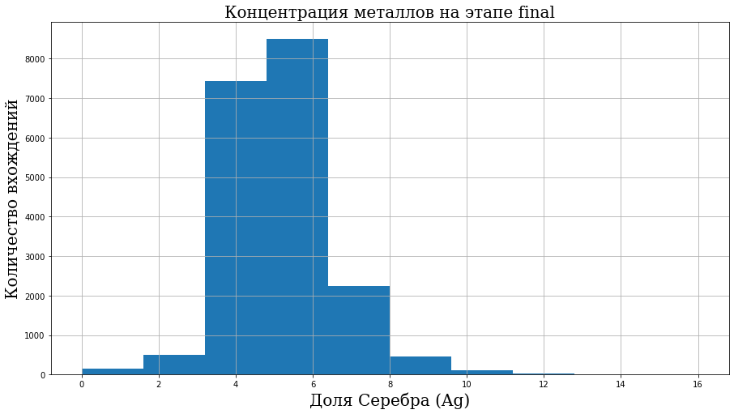

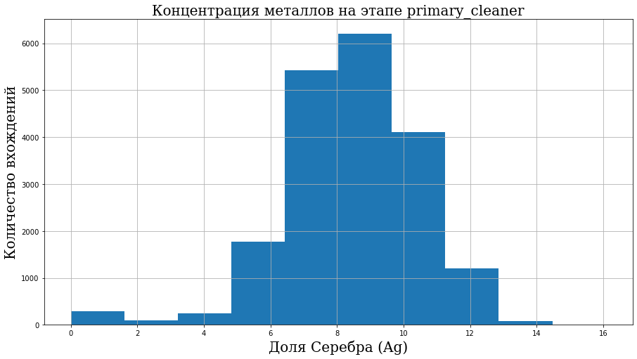

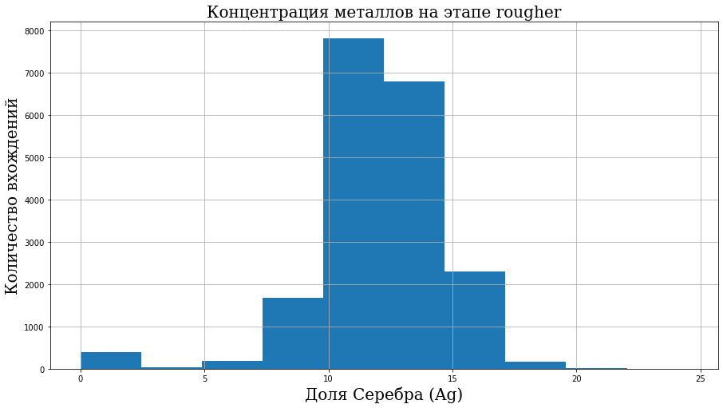

```python
for column in data_full[[x for x in data_train.columns if 'concentrate_ag' in x]].columns:
    data_full[column].hist(figsize=(15,8))
    name = ('.'.join(column.split('.')[:-2]))
    plt.title(f'Концентрация металлов на этапе {name}', fontdict=font)
    plt.xlabel('Доля Серебра (Ag)', fontdict=font)
    plt.ylabel('Количество вхождений', fontdict=font)
    plt.grid(True)
    plt.show()
```

```python
data_full[[x for x in data_train.columns if 'concentrate_ag' in x]].describe()
```

|  | final.output.concentrate_ag | primary_cleaner.output.concentrate_ag | rougher.output.concentrate_ag |
| --- | --- | --- | --- |
| count | 19438.000000 | 19439.000000 | 19439.000000 |
| mean | 5.168470 | 8.442408 | 11.994759 |
| std | 1.372348 | 2.054465 | 2.733862 |
| min | 0.000000 | 0.000000 | 0.000000 |
| 25% | 4.251240 | 7.263288 | 10.628337 |
| 50% | 5.066094 | 8.507298 | 12.098115 |
| 75% | 5.895527 | 9.809001 | 13.736996 |
| max | 16.001945 | 16.081632 | 24.480271 |

Что можно сказать о долях серебра на каждом из этапов обработки? Прежде всего, наибольшая часть серебра из исходного сырья уходит еще на этапе флотации. После этого с каждым этапом доля серебра в сырье уменьшается. Интересно то, что максимальная доля серебра в смеси после этапов первичной и вторичной отчисток практически не меняется, в то время как разница между этапами флотации и первичной чистки существенна. Можно предположить, что первичная и вторичная отчистка хуже справляется с крупными гранулами серебра - ведь его доля в сырье немаленькая.

Теперь перейдем к анализу свинца.

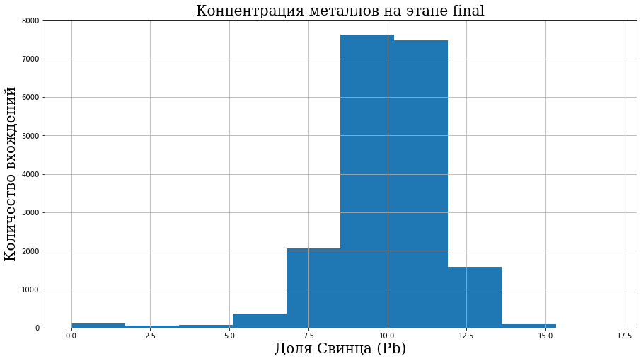

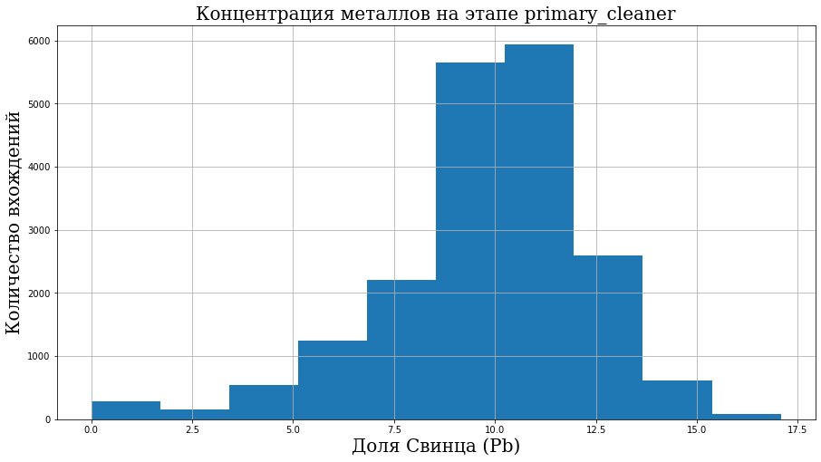

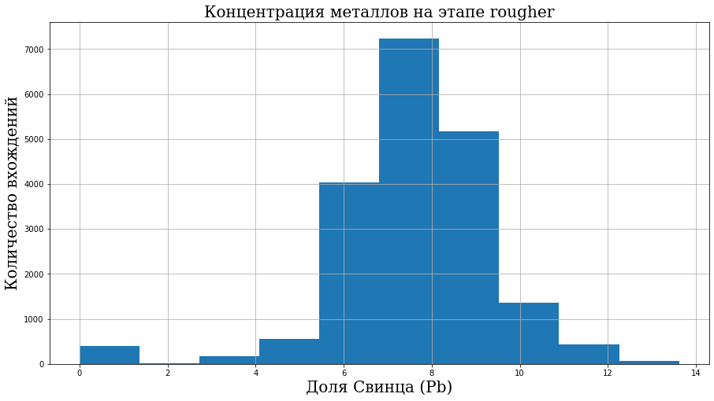

```python
for column in data_full[[x for x in data_train.columns if 'concentrate_pb' in x]].columns:
    data_full[column].hist(figsize=(15,8))
    name = ('.'.join(column.split('.')[:-2]))
    plt.title(f'Концентрация металлов на этапе {name}', fontdict=font)
    plt.xlabel('Доля Свинца (Pb)', fontdict=font)
    plt.ylabel('Количество вхождений', fontdict=font)
    plt.grid(True)
    plt.show()
```

```python
data_train[[x for x in data_train.columns if 'concentrate_pb' in x]].describe()
```

|  | final.output.concentrate_pb | primary_cleaner.output.concentrate_pb | rougher.output.concentrate_pb |
| --- | --- | --- | --- |
| count | 14149.000000 | 14149.000000 | 14149.000000 |
| mean | 10.132848 | 9.568544 | 7.664555 |
| std | 1.654925 | 2.709330 | 1.856279 |
| min | 0.000000 | 0.000000 | 0.000000 |
| 25% | 9.296833 | 8.315997 | 6.850501 |
| 50% | 10.297013 | 9.920598 | 7.760435 |
| 75% | 11.170578 | 11.298487 | 8.601927 |
| max | 17.031899 | 17.081278 | 13.617072 |

Тут мы наблюдаем несколько противоположную картину - свинец более сложно удаляется из исходного сырья. Об этом говорит тот факт, что его средняя доля растет от этапа к этапу.

В долевом отношении он в среднем занимает до 10% от сырья.

Наконец, рассмотрим наиболее важный показатель - содержание золота.

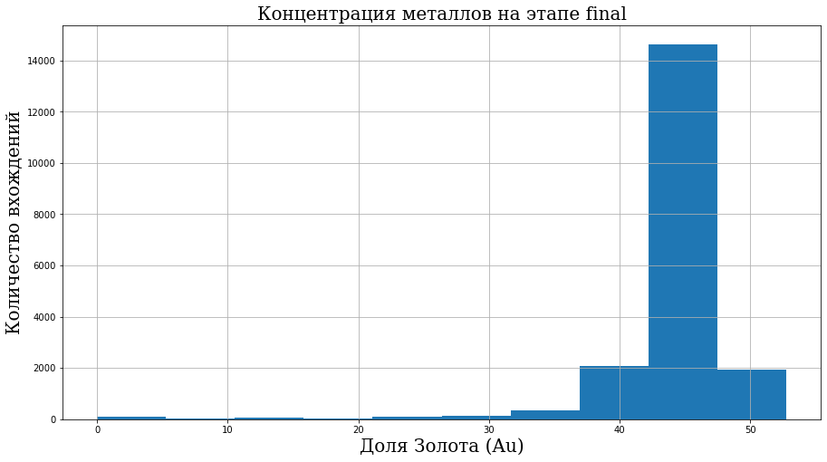

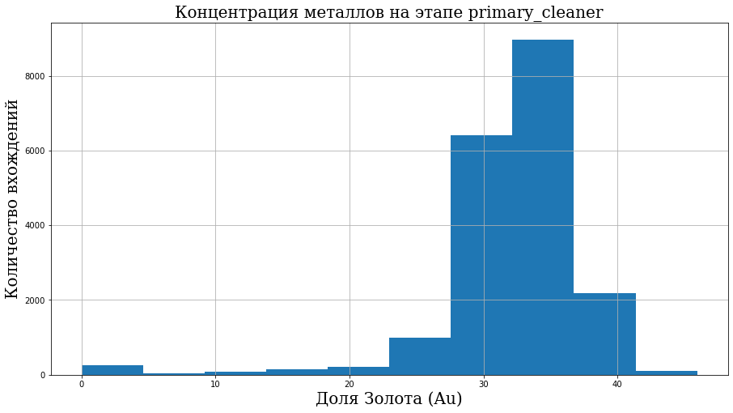

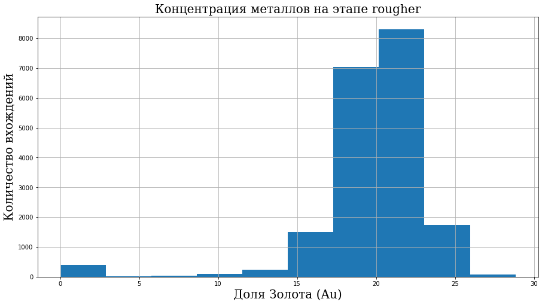

```python
for column in data_full[[x for x in data_train.columns if 'concentrate_au' in x]].columns:
    data_full[column].hist(figsize=(15,8))
    name = ('.'.join(column.split('.')[:-2]))
    plt.title(f'Концентрация металлов на этапе {name}', fontdict=font)
    plt.xlabel('Доля Золота (Au)', fontdict=font)
    plt.ylabel('Количество вхождений', fontdict=font)
    plt.grid(True)
    plt.show()
```

```python
data_train[[x for x in data_train.columns if 'concentrate_au' in x]].describe()
```

|  | final.output.concentrate_au | primary_cleaner.output.concentrate_au | rougher.output.concentrate_au |
| --- | --- | --- | --- |
| count | 14149.000000 | 14149.000000 | 14149.000000 |
| mean | 44.003792 | 32.386836 | 19.439958 |
| std | 4.905261 | 5.798843 | 3.765192 |
| min | 0.000000 | 0.000000 | 0.000000 |
| 25% | 43.276111 | 30.857764 | 18.432161 |
| 50% | 44.872436 | 33.225835 | 19.947312 |
| 75% | 46.166425 | 35.330145 | 21.392714 |
| max | 52.756638 | 45.933934 | 28.146838 |

Как можно заметить, средняя доля золота с каждым этапом повышается, что довольно-таки логично - предприятие делает акцент на добычу золота из руды. Между тем, даже после всех этапов обработки средняя доля золота даже не достигает половины от общего объема сырья - максимальная доля при этом чуть больше половины. Это означает, что необходимо проводить дополнительную работу над сырьем, если компания рассчитывает получить преимущественно золотую руду.

### Исследование распределения гранул сырья

Перейдем в следующему аналитическому блоку - анализу размеров гранул сырья. Нам необходимо проверить, существует ли существенное отличие между распределениями данного показателя на тренировочной и тестовой выборках. Если распределения сильно отличаются друг от друга, оценка модели будет неправильной.

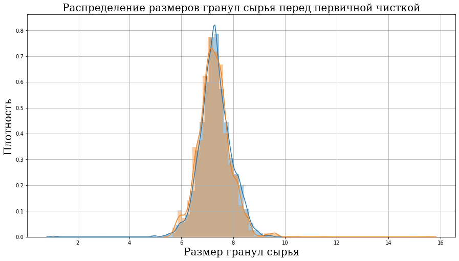

```python
plt.figure(figsize=(15,8))
sns_plot = sns.distplot(data_train['primary_cleaner.input.feed_size'])
sns_plot = sns.distplot(data_test['primary_cleaner.input.feed_size'])
plt.title(f'Распределение размеров гранул сырья перед первичной чисткой', fontdict=font)
plt.xlabel('Размер гранул сырья', fontdict=font)
plt.ylabel('Плотность', fontdict=font)
plt.grid(True)
plt.show()
```

[figure not shown]

```python
plt.figure(figsize=(15, 8))
sns_plot = sns.distplot(data_train['rougher.input.feed_size'])
sns_plot = sns.distplot(data_test['rougher.input.feed_size'])
plt.title(f'Распределение размеров гранул сырья перед первичной чисткой', fontdict=font)
plt.xlabel('Размер гранул сырья', fontdict=font)
plt.ylabel('Плотность', fontdict=font)
plt.grid(True)
plt.show()
plt.show()
```

Графический анализ показал, что распределение размера гранул сырья для тренировочных и тестовых данных можно считать похожим.

### Анализ суммарной концентрации веществ

Наконец, перейдем к завершающей части этапа анализа - исследованию суммарной концентрации всех веществ на разных этапах обработки. В частности мы рассмотрим следующие стадии: в сырье, в черновом и финальном концентратах.

```python
data_train['rougher_sum'] = data_train[['rougher.output.concentrate_ag', 'rougher.output.concentrate_pb',
                                            'rougher.output.concentrate_sol', 'rougher.output.concentrate_au']].sum(axis='columns')

data_train['primary_sum'] = data_train[['primary_cleaner.output.concentrate_ag', 'primary_cleaner.output.concentrate_pb',
                                            'primary_cleaner.output.concentrate_sol', 'primary_cleaner.output.concentrate_au']].sum(axis='columns')

data_train['final_sum'] = data_train[['final.output.concentrate_ag', 'final.output.concentrate_pb',
                                            'final.output.concentrate_sol', 'final.output.concentrate_au']].sum(axis='columns')

data_train['first_input_sum'] = data_train[['rougher.input.feed_ag', 'rougher.input.feed_pb',
                                            'rougher.input.feed_sol', 'rougher.input.feed_au']].sum(axis='columns')
```

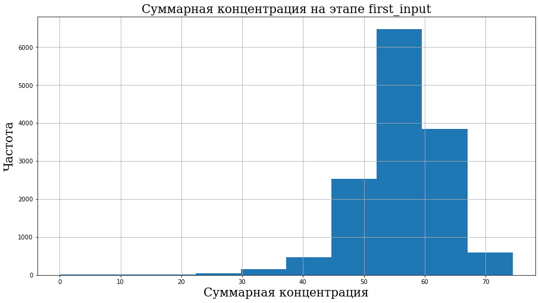

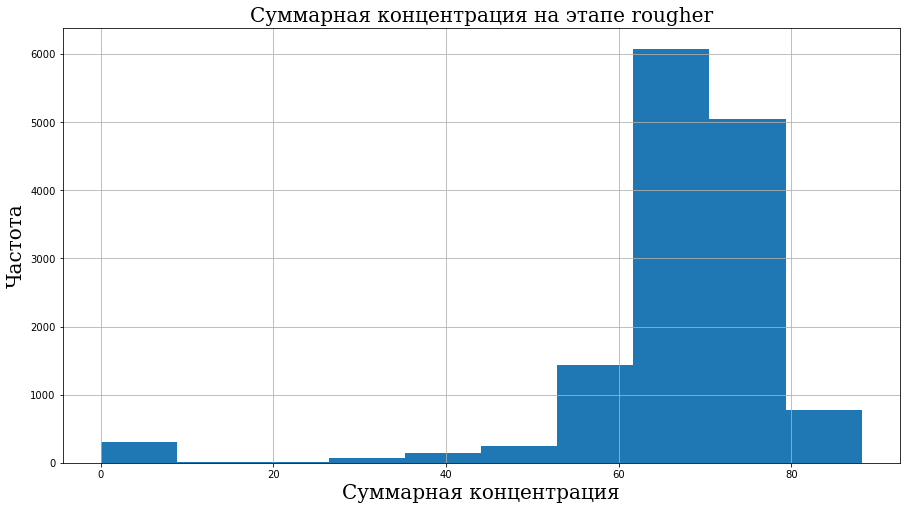

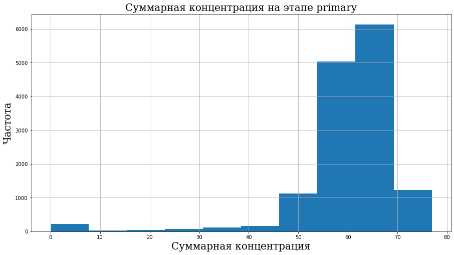

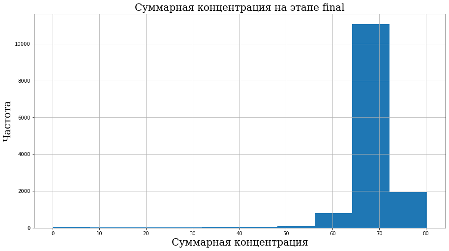

```python
for name in ['first_input_sum', 'rougher_sum', 'primary_sum', 'final_sum']:
    plt.figure(figsize=(15,8))
    data_train[name].plot(kind='hist')
    n = ('_'.join(name.split('_')[:-1]))
    plt.title(f'Суммарная концентрация на этапе {n}', fontdict=font)
    plt.xlabel('Суммарная концентрация', fontdict=font)
    plt.ylabel('Частота', fontdict=font)
    plt.grid(True)
    plt.show()
    plt.show()
```

В глаза бросается тот факт, что есть наблюдения, в которых суммарная концентрация всех веществ нулевая. Такой феномен наблюдается на всех исследуемых этапах. Есть две возможные причины возникновения такой аномалии - либо в данных присутствует ошибка, либо действительно есть сырье, в которое не входит ни один из рассматриваемых заказчиком составляющих.

Как поступить с такими наблюдениями? Нами было принято решение об их удалении. Несмотря на то, что мы допускаем реальность кейса существования исходного сырья, полностью лишенного учитываемых элементов, в рамках нашего кейса наличие таких наблюдений может, потенциально, привести к ошибке в расчетах на этапе моделирования. Кроме того, в пользу удаления таких наблюдений говорит тот факт, что они составляют лишь 3% от исходной выборки - мы потеряем не слишком существенную часть данных.

```python
index_1 = data_train[(data_train['rougher_sum'] == 0)&(data_train['rougher.output.recovery'] == 0)].index
data_train= data_train.drop(index_1)

index_2 = data_train[(data_train['final_sum'] == 0)&(data_train['final.output.recovery'] == 0)].index
data_train= data_train.drop(index_2).reset_index(drop=True)
```

Итак, нами был проведен выборочный детальный анализ исходного набора данных. В ходе работы были выявлены следующие моменты:

- Доля серебра сокращается с каждым этапом, в то время как доля свинца, напротив, растет. Доля золота также увеличивается с каждым этапом.
- Распределение размеров гранул сырья на тестовой и тренировочной выборках достаточно похожи, что позволяет нам спокойно строить общую для двух выборок модель.
- Суммарная концентрация рассматриваемых веществ может достигать нуля, что весьма странно в рамках рассматриваемого кейса. От таких наблюдений было решено избавиться.

## Моделирование эффективности

Перейдем к завершающему этапу нашего проекта - подготовке модели для прогнозирования эффективности обогащения. Нам будет необходимо спрогнозировать две величины - эффективность после флотации и итоговую эффективность. Итоговая модель выбирается на основе показателя суммарного sMAPE (Symmetric Mean Absolute Percentage Error).

Суммарная sMAPE рассчитывается следующим образом:

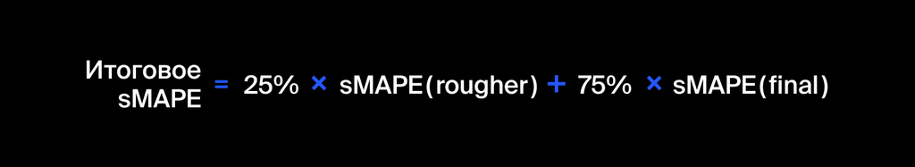

### sMAPE

Данные этап начнем с создания функции, которая автоматически будет рассчитывать sMAPE на основе фактического и предсказанного таргета.

```python
def symmetric_mean_absolute_percentage_error(target, prediction):
    numerator = np.abs(target - prediction)
    denominator = (np.abs(target) + np.abs(prediction)) / 2
    smape = 1 / len(target) * np.sum(numerator / denominator) * 100
    return smape
```

### Подбор моделей

Перейдем к этапу моделирования. Начнем с определения переменных и таргета для каждой из двух моделей. Не забудем исключить те переменные, которые не входят в тестовую выборку, а значит будут недоступны при проверке модели.

```python
target_rougher = data_train['rougher.output.recovery'].copy()
traget_final = data_train['final.output.recovery'].copy()

columns = data_train.columns.join(data_test.columns, how='inner')
features_final = data_train[columns].copy().drop(columns=['date', 'rougher.output.recovery', 'final.output.recovery'])
features_rougher = features_final[[x for x in features_final.columns if 'rougher' in x]].copy()
```

Проверим, что отбор признаков прошел успешно. Выведем список переменных, которые присутствуют в финальных характеристиках и отсутствуют в тестовых данных.

```python
[x for x in features_final.columns if x not in set(data_test.columns)]
```

```
[]
```

Также выведем список переменных, которые присутствуют в тестовых данных и отсутствуют в финальных характеристиках.

```python
[x for x in data_test.columns if x not in set(features_final.columns)]
```

```
['date', 'rougher.output.recovery', 'final.output.recovery']
```

Теперь перейдем к непосредственному моделированию. Поскольку перед нами стоит задача минимизации заданного параметра качества, куда удобнее будет использовать его в качестве скорера. Для этого создадим собственный скорер, по которому и будет отбираться лучшая в рамках одного типа модель.

```python
smape_scorer = make_scorer(symmetric_mean_absolute_percentage_error, greater_is_better=False)
```

В рамках данной работы мы рассмотрим по три модели для каждого из таргетов - линейную регрессию, случайный лес и градиентный бустинг.

Начнем с подбора модели для прогнозирования эффективности обогащения после этапа флотации.

```python
lin_reg = LinearRegression().fit(features_rougher, target_rougher)
cv_linreg_score = cross_val_score(lin_reg, features_rougher, target_rougher, scoring=smape_scorer, cv=5).mean()
print(f'Средняя оценка качества модели: {cv_linreg_score}%')
```

```
Средняя оценка качества модели: -6.660435975748051%
```

Мы получили значение параметра sMAPE равным 6.6% на кросс-валидации. Результат довольно неплох, однако более конкретные выводы можно будет сделать уже после получения аналогичного показателя у других моделей.

```python
forest = RandomForestRegressor(random_state=9, n_jobs=-1)
params_forest = {'max_depth': range (1, 10, 1), 'max_features': ['auto', 'sqrt', 'log2'],
                 'n_estimators': range(90, 120, 10)}
cv_forest = RandomizedSearchCV(forest, params_forest, cv=5, scoring=smape_scorer, n_jobs=-1)
cv_forest.fit(features_rougher, target_rougher)
cv_forest_score = cross_val_score(cv_forest, features_rougher, target_rougher, scoring=smape_scorer, cv=5).mean()
print(f'Средняя оценка качества модели: {cv_forest_score}%')
```

```
Средняя оценка качества модели: -6.501419697333452%
```

Как можно заметить, для случайного леса параметр sMAPE равняется 6.5% на кросс-валидации. Это несколько меньше аналогичного показателя у линейной регрессии, однако впереди еще необходимо проверить градиентный бустинг.

```python
cat = CatBoostRegressor(random_state=9, verbose=False)
params_cat = {'n_estimators': range(90, 120, 10),
               'depth': range (1, 10, 1), 'grow_policy': ['Depthwise']}
cv_cat = RandomizedSearchCV(cat, params_cat, cv=5, scoring=smape_scorer, n_jobs=-1)
cv_cat.fit(features_rougher, target_rougher)
cv_cat_score = cross_val_score(cv_cat, features_rougher, target_rougher, scoring=smape_scorer, cv=5).mean()
print(f'Средняя оценка качества модели: {cv_cat_score}%')
```

```
Средняя оценка качества модели: -6.7416042593599625%
```

Для градиентного бустинга параметр sMAPE равняется 6.7% на кросс-валидации. Это даже больше аналогичного значения у линейной регрессии. Однако окончательные выводы о моделях можно будет сделать только после подготовки моделей и для итогового коэффициента эффективности.

Перейдем к построению моделей для прогнозирования финальной эффективности обогащения. Также построим три модели.

```python
lin_reg_f = LinearRegression().fit(features_final, traget_final)
cv_linreg_score_f = cross_val_score(lin_reg_f, features_final, traget_final, scoring=smape_scorer, cv=5).mean()
print(f'Средняя оценка качества модели: {cv_linreg_score_f}%')
```

```
Средняя оценка качества модели: -10.99020051515803%
```

Для показателя финальной эффективности sMAPE линейной регрессии составляет почти 11%.

```python
forest_f = RandomForestRegressor(random_state=9, n_jobs=-1)
params_forest = {'max_depth': range (15, 30, 1), 'max_features': ['auto', 'sqrt', 'log2'],
                 'n_estimators': range(70, 120, 10)}
cv_forest_f = RandomizedSearchCV(forest, params_forest, n_iter=10, cv=5, scoring=smape_scorer, n_jobs=-1)
cv_forest_f.fit(features_final, traget_final)
cv_forest_score_f = cross_val_score(cv_forest_f, features_final, traget_final, scoring=smape_scorer, cv=5).mean()
print(f'Средняя оценка качества модели: {cv_forest_score_f}%')
```

```
Средняя оценка качества модели: -9.635818766197229%
```

Для показателя финальной эффективности sMAPE случайного леса составляет 9.6% на кросс-валидации. Это несколько меньше аналогичного показателя у линейной регрессии.

```python
cat = CatBoostRegressor(random_state=9, verbose=False)
params_cat = {'n_estimators': range(90, 120, 10),
               'depth': range (1, 10, 1), 'grow_policy': ['Depthwise']}
cv_cat_f = RandomizedSearchCV(cat, params_cat, n_iter=10, cv=5, scoring=smape_scorer, n_jobs=-1)
cv_cat_f.fit(features_final, traget_final)
cv_cat_score_f = cross_val_score(cv_cat_f, features_final, traget_final, scoring=smape_scorer, cv=5).mean()
print(f'Средняя оценка качества модели: {cv_cat_score_f}%')
```

```
Средняя оценка качества модели: -9.645154999727074%
```

Наконец, sMAPE градиентного бустинга для финальной эффективности составляет также 9.6% на кросс-валидации. Это несколько меньше аналогичного показателя у линейной регрессии, но больше по сравнению со случайным лесом.

Теперь, когда мы получили все необходимые промежуточные значения, перейдем к расчету итогового sMAPE и выбору лучшей модели.

```python
smape_linreg = cv_linreg_score*0.25+cv_linreg_score_f*0.75

print(f'Итоговое значение sMAPE для модели линейной регрессии {smape_linreg}%.')
```

```
Итоговое значение sMAPE для модели линейной регрессии -9.907759380305535%.
```

```python
smape_forest = cv_forest_score*0.25+cv_forest_score_f*0.75

print(f'Итоговое значение sMAPE для модели случайного леса {smape_forest}%.')
```

```
Итоговое значение sMAPE для модели случайного леса -8.852218998981284%.
```

```python
smape_cat = cv_cat_score*0.25+cv_cat_score_f*0.75

print(f'Итоговое значение sMAPE для модели градиентного бустинга {smape_cat}%.')
```

```
Итоговое значение sMAPE для модели градиентного бустинга -8.919267314635295%.
```

Как можно заметить, наиболее маленьким значением суммарного sMAPE обладают модели случайного леса. Градиентный бустинг несколько проигрывает им в качестве, а линейные регрессии показали наименьший результат по качеству. На основании итого в качестве итоговой модели мы выбираем модель случайного леса.

### Предсказание теста

Наконец, перейдем к проверке выбранной нами итоговой модели на тестовых данных. Для начала подготовим наши данные, после чего проведем необходимые рассчеты.

```python
target_test = data_test['rougher.output.recovery'].copy()
target_test_f = data_test['final.output.recovery'].copy()

features_final_test = data_test.copy().drop(columns=['date', 'rougher.output.recovery', 'final.output.recovery'])
features_rougher_test = features_final_test[[x for x in features_final.columns if 'rougher' in x]].copy()
```

```python
cv_forest_t = cross_val_score(cv_forest, features_rougher_test, target_test, scoring=smape_scorer, cv=5).mean()
cv_forest_t_f = cross_val_score(cv_forest_f, features_final_test, target_test_f, scoring=smape_scorer, cv=5).mean()

smape_forest_t =cv_forest_t*0.25+cv_forest_t_f*0.75

print(f'Средняя оценка качества модели после флотации: {cv_forest_t}%')
print(f'Средняя оценка качества финальной модели: {cv_forest_t_f}%')
print(f'Итоговое значение sMAPE для модели случайного леса {smape_forest_t}%.')
```

```
Средняя оценка качества модели после флотации: -10.820649457992712%
Средняя оценка качества финальной модели: -9.853445919292989%
Итоговое значение sMAPE для модели случайного леса -10.095246803967921%.
```

Между тем, для более объективной оценки качества теста дополнительно сравним полученные нами результаты с результатами, которые бы получались при использовании простейшей дамми регрессии.

Построим модель дамми регрессии, использовав в качестве предсказания медиану. При выборе стратегии мы руководствовались следующей логикой - расчет sMAPE довольно сильно похож на показатель MAE, для которого лучшей константной моделью является именно модель с использованием медианы. В таком случае будет наиболее логично использовать медиану и в рамках нашего кейса.

```python
from sklearn.dummy import DummyRegressor

dummy_reg = DummyRegressor(strategy='median')
dummy = dummy_reg.fit(features_rougher, target_rougher)
dummy_f = dummy_reg.fit(features_final, traget_final)
```

```python
cv_dummy_score = cross_val_score(dummy, features_rougher_test, target_test, scoring=smape_scorer, cv=5).mean()
cv_dummy_score_f = cross_val_score(dummy_f, features_final_test, target_test_f, scoring=smape_scorer, cv=5).mean()

print(f'Средняя оценка качества модели после флотации: {cv_dummy_score}%')
print(f'Средняя оценка качества финальной модели: {cv_dummy_score_f}%')
```

```
Средняя оценка качества модели после флотации: -8.2399208315271%
Средняя оценка качества финальной модели: -9.430222935079499%
```

```python
smape_dummy =cv_dummy_score*0.25+cv_dummy_score_f* 0.75
print(f'Итоговое значение sMAPE для модели случайного леса {smape_dummy}%.')
```

```
Итоговое значение sMAPE для модели случайного леса -9.1326474091914%.
```

Таким образом, пусть наша итоговая модель показала неплохое качество как на тренировочной, так и на тестовой выборках, она является недостаточно хорошей для фактического применения.

## Итоговые выводы

Итак, перед нами стояла задача разработки прототипа модели машинного обучения, которая будет помогать оптимизировать производство, чтобы не запускать предприятие с убыточными характеристиками. Достичь мы это должны были путем предсказывания коэффициента восстановления золота из золотосодержащей руды.

На вход мы получили три набора данных - тренировочный, тестовый и полный. Полный набор состоял из объединения тренировочного и более расширенного тестового набора. Первичный анализ данных показал, что в данных присутствуют наблюдения с пропущенными значениями - мы заполнили их основываясь на информации о наблюдение, идущем перед наблюдением с пропуском. Мы выбрали такой метод, поскольку нам было сказано, что данные отсортированы по времени и стоящие рядом наблюдения в целом похожи.

Нами также был проведен выборочный детальный анализ некоторых характеристик. В ходе такого анализа удалось выявить следующие закономерности. Доля серебра от общего сырья сокращается от этапа к этапу, в то время как доля свинца, напротив, растет. Доля золота также увеличивается с каждым этапом. Возможно, проводимых отчисток недостаточно, чтобы вычленить свинец из исходного сырья и необходимо проводить дополнительное очищение. Доля золота также увеличивается на каждом этапе, что, учитывая специфику деятельности компании, довольно логично.

Распределение размеров гранул сырья на тестовой и тренировочной выборках оказались похожи, что позволило нам спокойно построить общие для двух выборок модели. Наконец, было обнаружено, что суммарная концентрация рассматриваемых веществ может достигать нуля. От таких наблюдений было решено избавиться.

Наконец, нами были построены три типа моделей для прогнозирования коэффициента эффективности после флотации и вторичной отчистки. Для выбора лучшей модели использовался суммарный коэффициент sMAPE. По итогу, лучшее качество показала модель случайного леса. Именно ее мы выбрали в качестве итоговой.

Несмотря на то, что sMAPE, полученный как на тестовой, так и на тренировочной выборке, был не слишком высок, разработанной нами модели оказалось недостаточно для того, чтобы побить качество простейшей дамми регрессии, использующей медианное значение в качестве предсказателя.